# 84th MORS Text Analysis

**This work is currently on-going and being completed outside of duty hours. This represents the “do no spend too much time on it” version of the analysis.**

The Center for Army Analysis was asked by the Military Operations Research Society (MORS) to analyze the texts of abstracts submited for the 84th MORS symposium. The goal of the analysis was to determine if the abstracts would form clusters that are different than their current clustering (by working groups).

## Summary

Do the abstracts cluster in a way that makes reorganizing the MORS working groups logical and worthwhile?

The short answer is no. Many of the unique terms found in the corpus are also unique to an abstract. In other words the terms are not shared across abstracts. My hypothesis is that this is because MORS does not reject many abstracts sent for submission. This would lead to abstracts that are loosely tied to WG but not very specific to the WG.

The first piece of data that we have is the sparsity of the Document Term Matrix which lists all of the key terms in the corpus and how many times they appear in each document.

```r
dtm
```

```
## <<DocumentTermMatrix (documents: 383, terms: 7003)>>
## Non-/sparse entries: 31109/2651040
## Sparsity           : 99%
## Maximal term length: 26
## Weighting          : term frequency (tf)
```

```r
removeSparseTerms(dtm,0.90)
```

```
## <<DocumentTermMatrix (documents: 383, terms: 98)>>
## Non-/sparse entries: 6060/31474
## Sparsity           : 84%
## Maximal term length: 13
## Weighting          : term frequency (tf)
```

We’re left with a sparsity of 84% and only 98 terms remaining. This is further evidence that the corpus words are not shared between document because the only way to reduce the sparsity of the matrix is to remove terms.

However, all is not lost.

To determine the number of clusters we try to minimize the sum of squares error within each group.

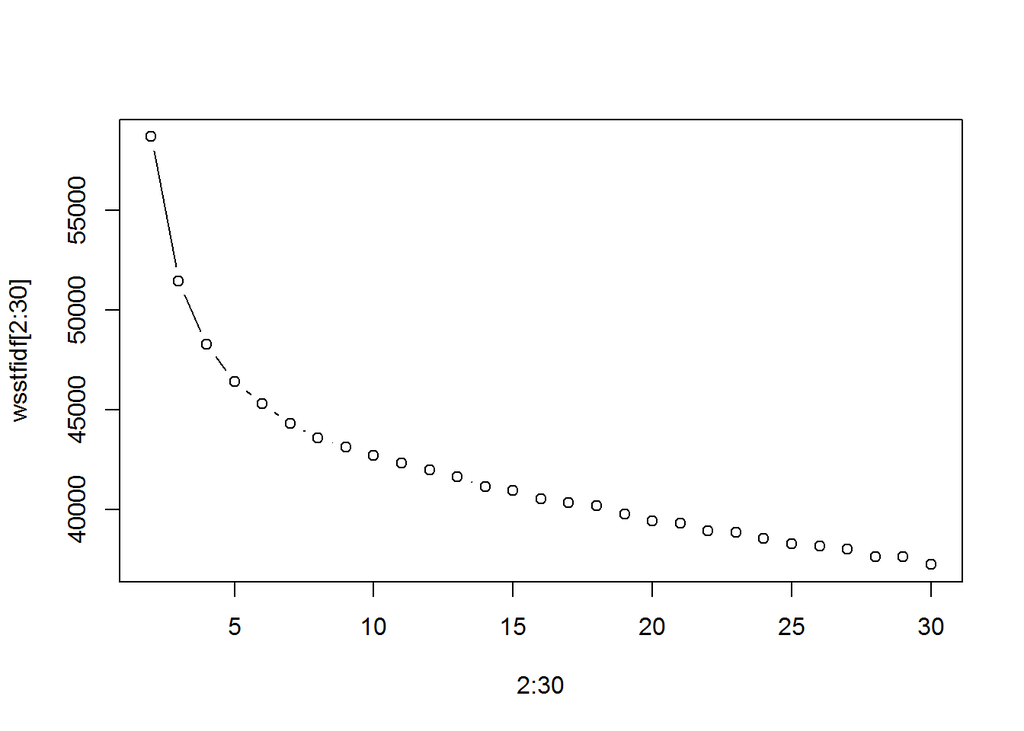

```r
mattfidf <- weightTfIdf(dtm)
disttfidf <- dist(mattfidf, method = "manhattan")
wsstfidf <- 2:30
for (i in 2:30) wsstfidf[i] <- sum(kmeans(disttfidf, centers = i, nstart = 25)$withinss)
plot(2:30, wsstfidf[2:30], type = "b")
```

We’re looking for the point where the rate of change for the SS error begins to decrease. You can see this around 5-10 clusters.

```r
sphericalmeans <- skmeans(mattfidf, 10)
sphericalmeans$cluster
```

```
##   1   2   3   4   5   6   7   8   9  10  11  12  13  14  15  16  17  18
##   9   1   3   5   5   3   7   5  10   7  10   8   7   4   9   9   5   8
##  19  20  21  22  23  24  25  26  27  28  29  30  31  32  33  34  35  36
##   5   9   1   3   7   7  10   5   6   3   7   1   9   6   4   5   9   5
##  37  38  39  40  41  42  43  44  45  46  47  48  49  50  51  52  53  54
##   7   3   5   5   5   5   9   9   3   3   3   2   2   8   3   1  10  10
##  55  56  57  58  59  60  61  62  63  64  65  67  68  69  70  71  72  73
##  10   6   3   7   5   8   8   5   1  10   1   8   7   8   5   1   3   3
##  74  75  76  77  78  79  80  81  82  83  84  85  86  87  88  89  90  91
##   3   2  10   3   9   9   3   7   2   9   7  10   4   7   5   5   3   2
##  92  93  94  95  96  97  98  99 100 101 102 103 104 105 106 107 108 109
##  10  10   5   9   9   6   3   5   5   7   6   5   5   3   6   4   7   5
## 110 111 112 113 114 115 116 117 118 119 120 121 122 123 124 125 126 127
##   5   2   3   9  10   5   3   6   7   5   1   9  10   7   5   3   5   4
## 128 129 130 131 132 133 134 135 136 137 138 139 140 141 142 143 144 145
```

[output cut: 29 more lines]

The 10 words associated with each cluster are:

```r
mfrq_words_per_cluster(sphericalmeans, dtm, unique = FALSE)
```

```
## $CLUSTER_1
##  operations        army      combat       model operational         set
##          20          17          17          17          17          16
##     mission    military         new       force
##          15          14          14          13
##
## $CLUSTER_2
##   operations        force         army presentation          air
##           18           17           15           15           14
##        model       system      systems         gaps     modeling
##           14           14           14           13           12
##
## $CLUSTER_3
##        model      systems  operational      mission        force
##           46           46           45           39           31
##      support       system presentation         test     security
##           31           29           28           28           27
##
## $CLUSTER_4
##        model    developed      testing         time       system
##           26           15           15           15           14
##     approach         fuel          one presentation      process
##           13           13           12           12           12
##
## $CLUSTER_5
##        model       system         cost  operational      systems
##           49           35           33           32           32
## presentation       future        force     approach         army
##           31           30           28           26           26
##
## $CLUSTER_6
##          air         cost        force         army  methodology
##           23           22           18           16           15
##      mission        model presentation        study requirements
##           15           15           15           15           14
##
## $CLUSTER_7
##   simulation      process        study          air        model
##           29           27           24           23           23
## capabilities      mission  operational       within     decision
##           22           22           22           20           19
##
## $CLUSTER_8
##         time        model   simulation       models        force
##           18           17           16           15           14
##     manpower optimization      support         army       repair
##           11           11           11           10           10
##
## $CLUSTER_9
##     decision        model     research   simulation  operational
##           21           20           17           16           15
##     aircraft       system intelligence  development      process
##           14           14           13           12           12
##
## $CLUSTER_10
##        army        cost     systems      system     defense     process
##          32          29          27          26          25          25
##       study        team operational        risk
##          24          24          23          23
```

The 10 unique words associated with each cluster are:

```r
mfrq_words_per_cluster(sphericalmeans, dtm, unique = TRUE)
```

```
## $CLUSTER_1
##        surgical            afsc             icd           niirs
##               8               7               6               6
##             qol          motion           mitre nonavailability
##               6               5               4               4
##            sdsr           syria
##               4               4
##
## $CLUSTER_2
##          dhs        crowd         jsps          tfp       advise
##            8            5            5            5            4
## universities          asu         bicc         coes        freak
##            4            3            3            3            3
##
## $CLUSTER_3
##     fitness       beeps         mtc    sampling  biometrics        cops
##          12           8           6           6           5           5
##         dst       fwtnp downscaling    ensemble
##           5           5           4           4
##
## $CLUSTER_4
##       htns        aav        mmh       cgfs      nvesd        amp
##          6          5          5          4          4          3
##        cab contractor        hdm  iteration
##          3          3          3          3
##
## $CLUSTER_5
##      amulet     cluster        fbar      afotec        book fragmenting
##           7           6           6           5           5           5
##        fuze        beam  evacuation    followon
##           5           4           4           4
##
## $CLUSTER_6
##      price     prices     satcom      nexus        png respective
##          6          6          6          5          5          5
##  irregular      crude        gen      plays
##          4          3          3          3
##
## $CLUSTER_7
##           esp           abi          cwam         squad         alpha
##             6             5             5             5             4
## decontaminant    devolution       ducting         rifle        attune
##             4             4             4             4             3
##
## $CLUSTER_8
##      othrs     clinic  terrorism      cdmps centrality       esbc
##          8          5          5          4          4          4
##       node      opral       devs       mals
##          4          4          3          3
##
## $CLUSTER_9
##          ped          lbc homelessness          pap          coa
##            7            6            5            5            4
##        ewcem         mtfs     embarked   incidences        links
##            4            4            3            3            3
##
## $CLUSTER_10
##       tenants       nonarmy          srdr         trust          acpa
##             8             7             7             7             6
## reimbursement         cobra          hash     splitting        afghan
##             6             5             5             5             4
```

## Preprocessing

### Abstract Corpus

```r
abstracts
```

```
## <<VCorpus>>
## Metadata:  corpus specific: 0, document level (indexed): 0
## Content:  documents: 383
```

This has a key metric - the sparsity of the matrix - which is 99% and means that 99% of the matrix is filled with 0s. This implies that there are a large number of terms that are not shared between documents.  
### Document Term Matrix

```r
dtm
```

```
## <<DocumentTermMatrix (documents: 383, terms: 7003)>>
## Non-/sparse entries: 31109/2651040
## Sparsity           : 99%
## Maximal term length: 26
## Weighting          : term frequency (tf)
```

```r
## This shows you words 150 to 160 for document 17.  These words did no appear within the document (but did elsewhere in the corpus)
inspect(dtm[17, 150:160])
```

```
## <<DocumentTermMatrix (documents: 1, terms: 11)>>
## Non-/sparse entries: 0/11
## Sparsity           : 100%
## Maximal term length: 12
## Weighting          : term frequency (tf)
##
##     Terms
## Docs accumulation accuracy accurate accurately aceit achievable achieve
##   17            0        0        0          0     0          0       0
##     Terms
## Docs achieved achievement achieves achieving
##   17        0           0        0         0
```

## Distance and normalization calculations

From the DTM we can begin to cluster the abstracts. Clustering algorithms depend on the notion of distance in order to determine how documents are similar or different. The distance calculation occurs on a normalized or weighted DTM. This is to ensure that longer documents, for frequent words do not disproportionately affect the results. The most common method and one used here is the term frequency - inverse document frequency. So first we must calculate a distance matrix - this tells you how “far” away each document is from each other.

```r
#normalization Calcs

mattfidf <- weightTfIdf(dtm)


disttfidf <- dist(mattfidf, method = "manhattan")
distnorm <- dist(matnormal, method = "manhattan")
```

Clustering algorithms require an input that tells the algorithm the number of clusters to make. There are several heuristic methods for determing what this number should be. One of the most common ones is to plot the sum of squares error for each group. The point on the plot where the error starts to level out (the elbow in the curve) is a good starting point for how many clusters you should create.

```r
wss <- 2:30
for (i in 2:30) wss[i] <- sum(kmeans(distnorm, centers = i, nstart = 25)$withinss)
```

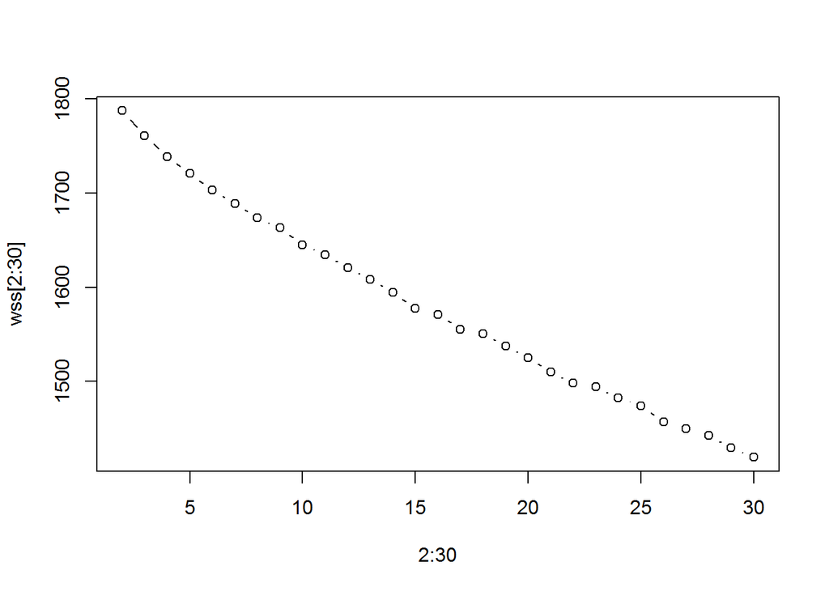

```r
plot(2:30, wss[2:30], type = "b")
```

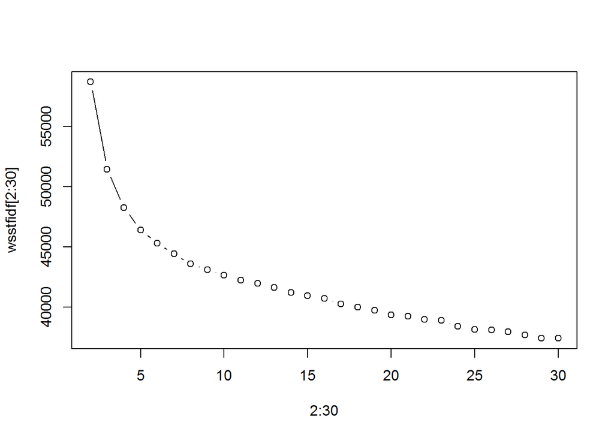

```r
wsstfidf <- 2:30
for (i in 2:30) wsstfidf[i] <- sum(kmeans(disttfidf, centers = i, nstart = 25)$withinss)
plot(2:30, wsstfidf[2:30], type = "b")
```

Using the tfidf weighting this implies that there should be about 5 +/-1 with a max of 10 clusters.

```r
tfidfclust <- hclust(distnorm, "ward.D2")

dendroNetwork(tfidfclust,  height = 6000, width = 2000, fontSize = 6,
              textColour = c("brown","light blue","pink","gray","tan","red", "blue", "orange","black","green")[cutree(tfidfclust, 5)],
              treeOrientation = "horizontal",zoom = TRUE,linkType = "elbow",nodeStroke="grey")
```

[interactive chart not shown]

```r
normclust <- hclust(distnorm, "ward.D2")

dendroNetwork(normclust,  height = 6000, width = 2000, fontSize = 6,
              textColour = c("brown","light blue","pink","gray","tan","red", "blue", "orange","black","green")[cutree(normclust, 5)],
              treeOrientation = "horizontal",zoom = TRUE,linkType = "elbow",nodeStroke="grey")
```

[interactive chart not shown]